# Reducing Fatigue in Long COVID: A Community Treatment Analysis

## 9. What Patients Are Saying *(experimental)*

Quotes from fatigue reporters who discussed specific treatments. Each quote is drawn from `posts.body_text`, filtered to users in the fatigue cohort who also have treatment reports. Dates are included. At least one quote complicates the main narrative.

Selected Patient Quotes

> **Magnesium** (1775139392): "*It's individual but I was highly deficient in chromium, magnesium and copper at least...*"

> **Magnesium** (1774462996): "*Then, Moon Juice Magnesiu-OM (3 types of chelated magnesium and L-theanine) mixed in tart cherry juice (melatonin and tryptophan) 1-2 hours before bed...*"

> **Magnesium** (1774654420): "*5 again and not really doing better) – Magnesium did nothing There’s a lot more but it gets overwhelming fast, especially with brain fog...*"

> **B Vitamins** (1775837044): "*Also I know they was dumping heparin because I had 30-40 bruises all over my body and my periods were...*"

> **B Vitamins** (1774117639): "*In order to avoid flare ups and PEM, I basically do nothing...*"

## 10. Tiered Treatment Recommendations for Fatigue

Based on the fatigue-specific analysis above, treatments are classified into three evidence tiers based on sample size and statistical significance against the 50% baseline.

★★★ Strong Evidence (8 treatments)

| Treatment | n | Pos Rate | CI Low | CI High | p-value | NNT | Avg Score |
| --- | --- | --- | --- | --- | --- | --- | --- |
| magnesium | 36 | 92% | 0.78 | 0.97 | 0.0000 | 2.4 | +0.82 |
| vitamin d | 46 | 83% | 0.69 | 0.91 | 0.0000 | 3.1 | +0.63 |
| nattokinase | 33 | 82% | 0.66 | 0.91 | 0.0002 | 3.1 | +0.54 |
| low dose naltrexone | 125 | 73% | 0.64 | 0.80 | 0.0000 | 4.4 | +0.45 |
| nicotine | 48 | 71% | 0.57 | 0.82 | 0.0028 | 4.8 | +0.38 |
| probiotics | 31 | 74% | 0.57 | 0.86 | 0.0053 | 4.1 | +0.46 |
| antihistamines | 77 | 62% | 0.51 | 0.72 | 0.0198 | 8.1 | +0.22 |
| coq10 | 39 | 67% | 0.51 | 0.79 | 0.0266 | 6.0 | +0.29 |

★★ Moderate Evidence (46 treatments)

| Treatment | n | Pos Rate | CI Low | CI High | p-value | NNT | Avg Score |
| --- | --- | --- | --- | --- | --- | --- | --- |
| b vitamins | 19 | 95% | 0.75 | 0.99 | 0.0000 | 2.2 | +0.88 |
| quercetin | 19 | 95% | 0.75 | 0.99 | 0.0000 | 2.2 | +0.89 |
| l-theanine | 8 | 100% | 0.68 | 1.00 | 0.0039 | 2.0 | +1.00 |
| vitamin b complex | 8 | 100% | 0.68 | 1.00 | 0.0039 | 2.0 | +1.00 |
| mestinon | 8 | 100% | 0.68 | 1.00 | 0.0039 | 2.0 | +0.88 |
| guanfacine | 13 | 92% | 0.67 | 0.99 | 0.0017 | 2.4 | +0.80 |
| vitamin c | 28 | 82% | 0.64 | 0.92 | 0.0005 | 3.1 | +0.56 |
| electrolyte | 27 | 81% | 0.63 | 0.92 | 0.0008 | 3.2 | +0.61 |
| aspirin | 11 | 91% | 0.62 | 0.98 | 0.0059 | 2.4 | +0.82 |
| fish oil | 11 | 91% | 0.62 | 0.98 | 0.0059 | 2.4 | +0.80 |
| magnesium glycinate | 15 | 87% | 0.62 | 0.96 | 0.0037 | 2.7 | +0.73 |
| b12 | 21 | 81% | 0.60 | 0.92 | 0.0036 | 3.2 | +0.67 |
| mast cell activation syndrome | 10 | 90% | 0.60 | 0.98 | 0.0107 | 2.5 | +0.80 |
| omega-3 | 17 | 82% | 0.59 | 0.94 | 0.0064 | 3.1 | +0.65 |
| antivirals | 13 | 85% | 0.58 | 0.96 | 0.0112 | 2.9 | +0.65 |

★ Preliminary Evidence (92 treatments)

| Treatment | n | Pos Rate | CI Low | CI High | p-value | NNT | Avg Score |
| --- | --- | --- | --- | --- | --- | --- | --- |
| novavax vaccine | 7 | 100% | 0.65 | 1.00 | 0.0078 | 2.0 | +0.98 |
| Advil | 6 | 100% | 0.61 | 1.00 | 0.0156 | 2.0 | +0.83 |
| ginger | 6 | 100% | 0.61 | 1.00 | 0.0156 | 2.0 | +1.00 |
| acetyl-L-carnitine | 6 | 100% | 0.61 | 1.00 | 0.0156 | 2.0 | +0.97 |
| dextromethorphan | 6 | 100% | 0.61 | 1.00 | 0.0156 | 2.0 | +1.00 |
| montelukast | 6 | 100% | 0.61 | 1.00 | 0.0156 | 2.0 | +1.00 |
| vitamin b2 | 6 | 100% | 0.61 | 1.00 | 0.0156 | 2.0 | +1.00 |
| thymosin alpha 1 | 6 | 100% | 0.61 | 1.00 | 0.0156 | 2.0 | +1.00 |
| lda | 6 | 100% | 0.61 | 1.00 | 0.0156 | 2.0 | +0.99 |
| cannabis | 6 | 100% | 0.61 | 1.00 | 0.0156 | 2.0 | +0.92 |
| lumbrokinase | 6 | 100% | 0.61 | 1.00 | 0.0156 | 2.0 | +0.92 |
| vitamin b1 | 5 | 100% | 0.57 | 1.00 | 0.0312 | 2.0 | +0.90 |
| pregabalin | 5 | 100% | 0.57 | 1.00 | 0.0312 | 2.0 | +0.80 |
| vitamin k2 | 5 | 100% | 0.57 | 1.00 | 0.0312 | 2.0 | +1.00 |
| turmeric | 5 | 100% | 0.57 | 1.00 | 0.0312 | 2.0 | +1.00 |

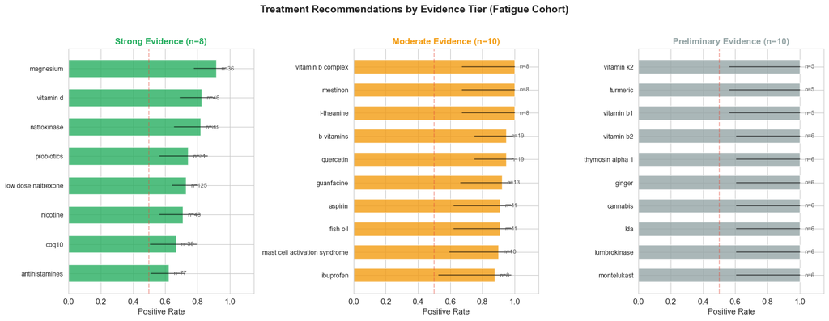

**Reading this chart:** Treatments are grouped by evidence strength. The red dashed line marks 50% (no better than chance). Whiskers show 95% Wilson confidence intervals. Treatments to the right of the line with non-overlapping CIs represent meaningful positive signals.